# Clinical Predictors of Type 2 Diabetes

Abderrezzaq KADOUCHE

## **Introduction**

Type 2 diabetes is a major public health challenge characterized by chronic hyperglycemia. Because metabolic abnormalities often develop silently over years, many patients remain undiagnosed until irreversible microvascular or macrovascular complications emerge. Identifying these predictors is therefore essential to improve early detection.

## **Objective**

The primary objective of this study is to identify the specific clinical and physiological factors that predict the onset of diabetes.

## **Data source**

This research utilizes a synthetic database to replicate the statistical properties of the historical medical study conducted by Smith, Everhart, Dickson, Knowler, and Johannes (1988). The original cohort targeted high-risk individuals, specifically female patients of Pima Native American heritage aged 21 and older, monitored by the National Institute of Diabetes and Digestive and Kidney Diseases (NIDDK).

## **Variable Specifications**

This dataset contains 9 variables, including 8 clinical predictors and 1 binary outcome variable:

- `pregnant`: **Number of times pregnant**. Counts the patient’s total number of pregnancies.
- `glucose`: **Plasma glucose concentration**. Measured during a 2-hour oral glucose tolerance test.
- `pressure`: **Diastolic blood pressure**. Measured in millimeters of mercury (mm Hg).
- `triceps`: **Triceps skin fold thickness**. Measured in millimeters (mm) to estimate subcutaneous fat.
- `insulin`: **2-hour serum insulin**. Measured in milli-international units per liter (mu U/ml).
- `mass`: **Body mass index (BMI)**. Calculated as weight in kilograms divided by height in meters squared ($kg/m^2$).
- `pedigree`: **Diabetes pedigree function**. A score that represents the genetic risk based on family history.
- `age`: **Age**. The patient’s age in years.
- `diabetes`: Binary indicator representing the test result for diabetes (positive / negative).

## **Descriptive analysis of continuous variables**

```r
library(prettyR)

vars_quanti <- c("pregnant", "glucose", "pressure", "triceps", "insulin", "mass", "pedigree", "age")

describe(
SynthDiabetes2[, vars_quanti],
num.desc = c("min", "max", "mean", "median", "sd", "valid.n")
)
```

```
## Description of SynthDiabetes2[, vars_quanti]
```

```
##
##  Numeric
##            min    max   mean median     sd valid.n
## pregnant  0.00  13.00   4.58   3.00   3.88     768
## glucose  57.00 199.00 125.30 119.00  31.59     763
## pressure 24.00 108.00  72.59  72.00  12.19     733
## triceps   7.00  63.00  29.46  30.00   9.96     517
## insulin  14.00 846.00 159.05 125.00 123.34     363
## mass     18.20  59.40  32.87  32.80   7.02     755
## pedigree  0.08   2.42   0.48   0.37   0.36     768
## age      21.00  81.00  33.05  28.00  11.94     768
```

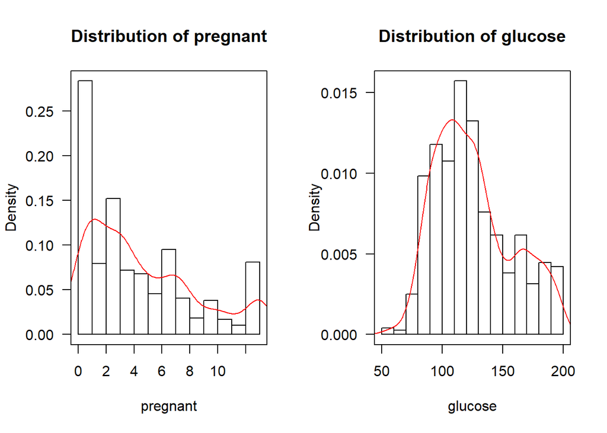

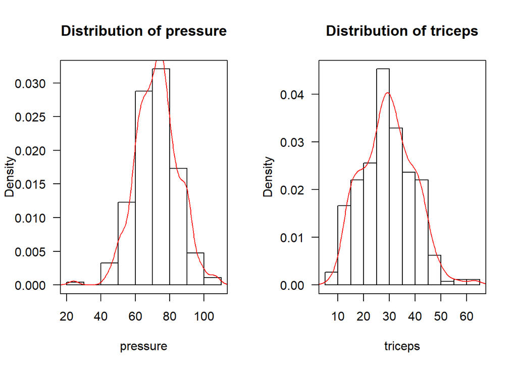

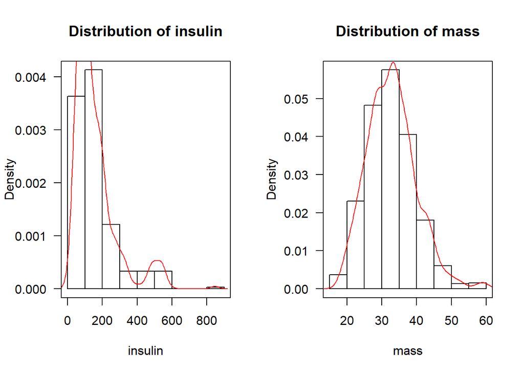

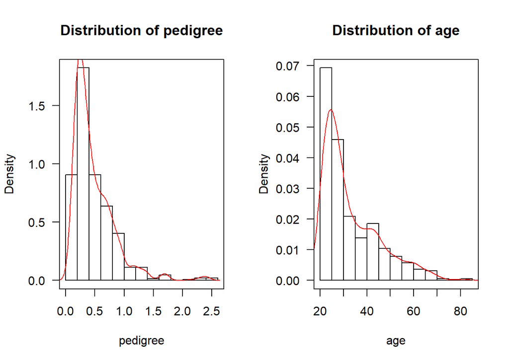

```r
par(mfrow = c(1, 2))
# Boucle sur toutes les variables quantitatives avec courbe de densité

for (var in vars_quanti) {
# 1. Tracer l'histogramme en mode "densité de probabilité" (prob = TRUE)
hist(SynthDiabetes2[[var]],
main = paste("Distribution of", var), # Titre dynamique
xlab = var,                           # Nom de la variable sur l'axe X
ylab = "Density",                     # L'axe Y devient la Densité
las  = 1,  # Labels horizontaux
col  = "white",                       # Barres blanches
border = "black",                     # Contours noirs
prob = TRUE)                          # OBLIGATOIRE pour la densité
# 2. Calculer et superposer la courbe de densité
# na.rm = TRUE est crucial car il peut y avoir des NA dans la colonne 'nodes'
lines(density(SynthDiabetes2[[var]], na.rm = TRUE),
col = "red",                         # Courbe en rouge pour le contraste
lwd = 1)                             # Épaisseur de la ligne
# 3. AJOUT DU CADRE AUTOUR DU GRAPHIQUE
box(col = "black", lwd = 1)
}
```

## **Descriptive analysis of categorical variables**

```r
library(gtsummary)

library(dplyr)

library (forcats)

SynthDiabetes2 %>%
select(diabetes) %>%
  # 1. On renomme d'abord les modalités
  mutate(diabetes = fct_recode(diabetes,
                               "Negative" = "neg",
                               "Positive" = "pos")) %>%
tbl_summary(
label = list(
  diabetes ~ "Diabetes"),
statistic = all_categorical() ~ "{n} ({p}%)",
digits    = all_categorical() ~ list(0, 1),
missing_text = "Missing"
) %>%
bold_labels()
```

| **Characteristic** | **N = 768**<sup>1</sup> |
| --- | --- |
| Diabetes |  |
| Negative | 488 (63.5%) |
| Positive | 280 (36.5%) |

<sup>1</sup> n (%)

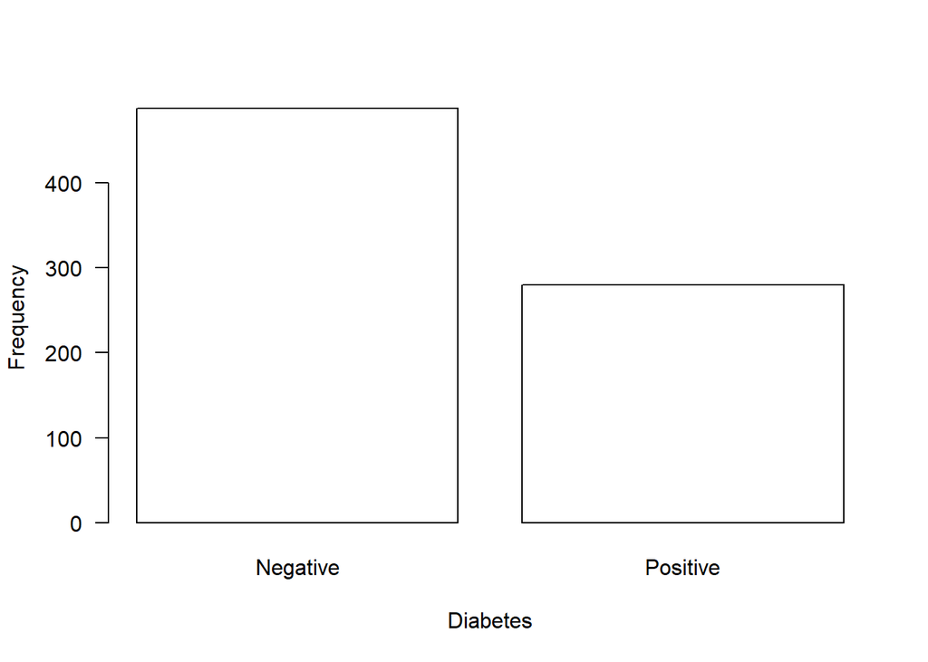

```r
# ── 1. diabetes──────────────────────────────────────
barplot(
  table(SynthDiabetes2$diabetes),
  ylab      = "Frequency",
  xlab      = "Diabetes",
  names.arg = c("Negative", "Positive"),
  col       = "white",
  border    = "black",
  las       = 1,
  cex.names = 1.0,
  cex.lab   = 1.0
)
```

## **Missing data**

An analysis of the missingness patterns revealed a critical methodology challenge, particularly regarding `insulin` and `triceps` which present missingness rates of 52.73% and 32.68% respectively. In clinical settings, collecting 2-hour serum insulin levels and measuring triceps skinfold thickness require specific diagnostic tools and specialized procedures, making them frequently missing from standard patient charts. Conversely, other health indicators such as `glucose`, `pressure`, and `mass` show very low missingness rates (< 5%). Conducting a strict complete-case analysis on all nine variables would cause the sample size to plummet from 768 to 361 observations, which represents a data loss of 53%, sacrificing over half of the data and severely compromising the model’s statistical power.

```r
tab_NA <- data.frame(
  Variables = names(SynthDiabetes2),
  n_NA = colSums(is.na(SynthDiabetes2)),
  percent_NA = round(colMeans(is.na(SynthDiabetes2)) * 100, 2),
  row.names = NULL )

print(tab_NA)
```

```
##   Variables n_NA percent_NA
## 1  pregnant    0       0.00
## 2   glucose    5       0.65
## 3  pressure   35       4.56
## 4   triceps  251      32.68
## 5   insulin  405      52.73
## 6      mass   13       1.69
## 7  pedigree    0       0.00
## 8       age    0       0.00
## 9  diabetes    0       0.00
```

### **Duplicate Record Detection**

Prior to fitting the statistical model, the dataset was audited to ensure the independence of observations. The analysis flagged exactly one perfect duplicate record in the dataset, with a redundant copy identified at row 436. This duplicate observation was removed from the dataset.

```r
#Vérifier les doublons
sum(duplicated(SynthDiabetes2))
```

```
## [1] 1
```

```r
which(duplicated(SynthDiabetes2) ==TRUE) #n°436
```

```
## [1] 436
```

```r
library(dplyr)

# Trouver l'index de la copie et de l'original
original <- which(duplicated(SynthDiabetes2, fromLast = TRUE))
copie <- which(duplicated(SynthDiabetes2))

# Afficher les deux numéros de lignes
cat("La ligne originale est la ligne numéro :", original, "\n")
```

```
## La ligne originale est la ligne numéro : 413
```

```r
cat("La ligne dupliquée (la copie) est la ligne numéro :", copie, "\n")
```

```
## La ligne dupliquée (la copie) est la ligne numéro : 436
```

```r
SynthDiabetes2[c(original, copie), ]
```

```
##     pregnant glucose pressure triceps insulin mass pedigree age diabetes
## 413        0     181       60      18     127 24.9    0.259  27      pos
## 436        0     181       60      18     127 24.9    0.259  27      pos
```

```r
data <- SynthDiabetes2[-436, ]
```

### **Missing Data Management**

A complete-case analysis was applied. This approach filters the dataset to retain only the observations with fully documented records across all 9 variables, including `insulin` and `triceps`. While this strategy significantly reduces the final sample size to 361 observations due to the high missingness rates in insulin and skinfold measurements, it allows for a comprehensive model that evaluates the simultaneous impact of every studied variable.

```r
complete_data <- na.omit(data)

sum(is.na(complete_data))
```

```
## [1] 0
```

```r
nrow(complete_data)
```

```
## [1] 361
```

```r
round((nrow(SynthDiabetes2) - nrow(complete_data)) / nrow(SynthDiabetes2) * 100, 1)
```

```
## [1] 53
```

## **Statistical Modeling and Diagnostics**

To evaluate the combined influence of the studied physiological indicators on the outcome, a multiple logistic regression model was implemented.

```r
# Ajustement du modèle : régression logistique multiple

mod <- glm(diabetes ~ ., data = complete_data, family = binomial)
```

```r
# Vérifier les conditions de validité :

#1) variable à expliquer binaire

#2) indépendance des observations


#3) au moins 5-10 évènements par variable explicative => OK

table(complete_data$diabetes)
```

```
##
## neg pos
## 242 119
```

```r
#nM+ = 119
```

```r
#4) Absence de multicolinéarité => OK (VIF < 5)
library(car)
vif(mod) # Calcul du Variance Inflation Factor (VIF)
```

```
## pregnant  glucose pressure  triceps  insulin     mass pedigree      age
## 1.977891 1.280652 1.127802 1.471287 1.175049 1.576580 1.034472 1.850705
```

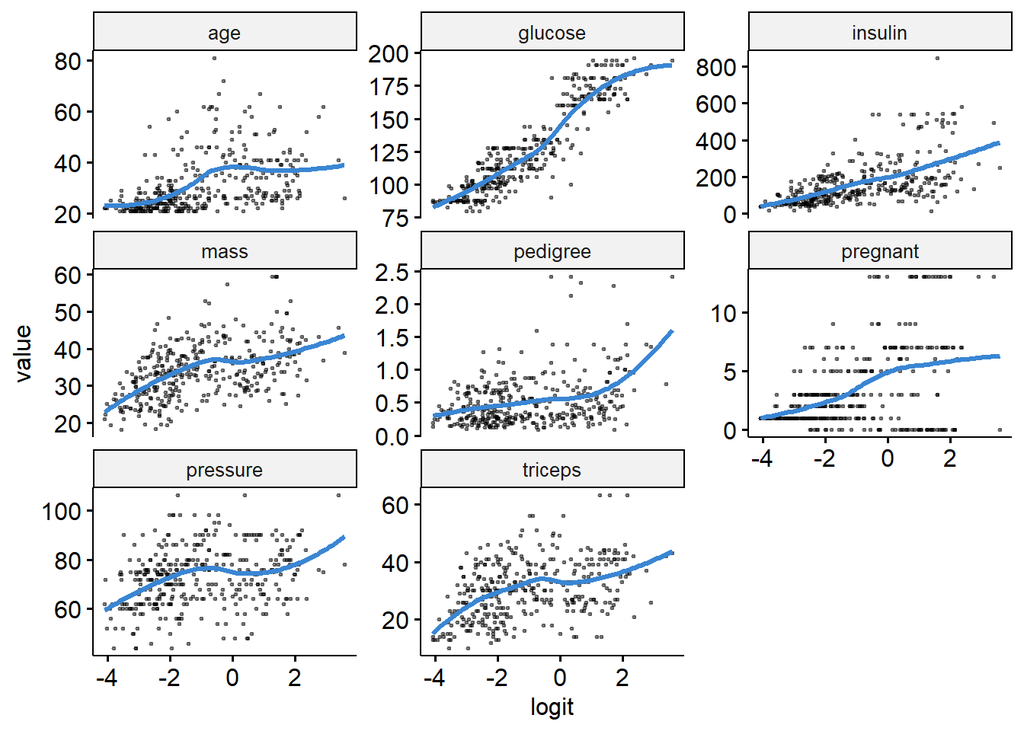

```r
#5) Linéarité du logit pour chaque variable explicative quantitative
#La régression logistique suppose que chaque prédicteur continu est linéaire par rapport au logit (log-odds), et non à la probabilité.

library(ggpubr)


probabilities <- predict(mod, type = "response")

# numeric predictors + the logit, reshaped long
num <- complete_data[sapply(complete_data, is.numeric)]

logit <- log(probabilities / (1 - probabilities))
long <- data.frame(
  logit     = rep(logit, ncol(num)),
  predictor = rep(names(num), each = nrow(num)),
  value     = unlist(num)
)

ggscatter(long, x = "logit", y = "value", size = 0.5, alpha = 0.4,
          add = "loess", add.params = list(color = "#3a86d4")) +
  facet_wrap(~ predictor, scales = "free_y")
```

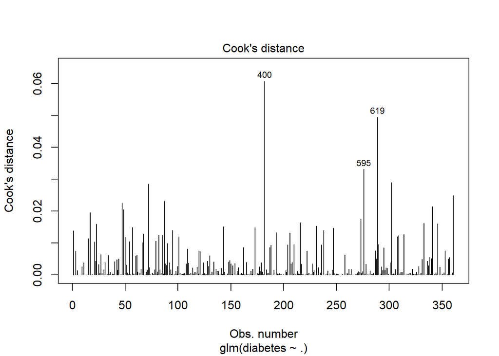

```r
#6) Absence de valeurs influentes excessives

#La distance de Cook permet de repérer si certains patients influencent de manière disproportionnée les coefficients du modèle. (seuil critique = 1)


# 1. Graphique de la distance de Cook
plot(mod, which = 4)
```

```r
# 2. Extraction des lignes dont la distance de Cook dépasse le seuil de 4/n
seuil_cook <- 4 / nrow(complete_data)
influential_obs <- which(cooks.distance(mod) > seuil_cook)

# Afficher les numéros de lignes des profils influents
print(influential_obs)
```

```
##   7  27  30  46  95  97 104 125 150 162 176 181 192 212 229 320 379 400 421 463
##   1  15  17  23  47  48  50  57  67  72  82  85  87  95 101 143 173 182 193 206
## 482 505 515 538 586 595 619 647 661 666 675 713 726 734 766
## 216 231 238 247 273 276 289 302 308 309 314 333 341 346 361
```

```r
#Même si les lignes 400, 619 et 595 se détachent nettement des autres, leur valeur maximale reste extrêmement basse (0.06, ce qui est très loin du seuil critique de 1).

#Condition: OK. Il n'y a aucun point excessivement aberrant ou influent capable de fausser à lui seul les conclusions de la régression logistique.
```

# **Results**

### Non-Significant Predictors

- **Body Mass Index (`mass`):** Although displaying a positive trend, the effect was not significant (β = 0.0396, OR = 1.04, p = 0.1138).
- **2-Hour Serum Insulin (`insulin`):** The effect was negligible and non-significant (β = 0.0018, OR = 1.00, p = 0.1543).
- **Triceps Skin Fold Thickness (`triceps`):** Showed no significant relationship (β = 0.0212, OR = 1.02, p = 0.2418).
- **Age (`age`):** Did not reach the significance threshold (β = 0.0159, OR = 1.02, p = 0.3271).
- **Diastolic Blood Pressure (`pressure`):** Showed non-significant coefficient (β = 0.0080, OR = 1.01, p = 0.5290).
- **Number of Pregnancies (`pregnant`):** Displayed the highest p-value among all predictors (β = 0.0197, OR = 1.02, p = 0.7143).

```r
summary(mod)
```

```
##
## Call:
## glm(formula = diabetes ~ ., family = binomial, data = complete_data)
##
## Coefficients:
##              Estimate Std. Error z value Pr(>|z|)
## (Intercept) -9.451614   1.298185  -7.281 3.32e-13 ***
## pregnant     0.019723   0.053869   0.366   0.7143
## glucose      0.035637   0.005252   6.786 1.15e-11 ***
## pressure     0.007978   0.012675   0.629   0.5290
## triceps      0.021169   0.018084   1.171   0.2418
## insulin      0.001775   0.001246   1.425   0.1543
## mass         0.039616   0.025052   1.581   0.1138
## pedigree     0.899170   0.352956   2.548   0.0108 *
## age          0.015850   0.016174   0.980   0.3271
## ---
## Signif. codes:  0 '***' 0.001 '**' 0.01 '*' 0.05 '.' 0.1 ' ' 1
##
## (Dispersion parameter for binomial family taken to be 1)
##
##     Null deviance: 457.69  on 360  degrees of freedom
## Residual deviance: 307.21  on 352  degrees of freedom
## AIC: 325.21
##
## Number of Fisher Scoring iterations: 5
```

```r
round(exp(cbind(OR = coef(mod), confint(mod))), 2)
```

```
##               OR 2.5 % 97.5 %
## (Intercept) 0.00  0.00   0.00
## pregnant    1.02  0.92   1.14
## glucose     1.04  1.03   1.05
## pressure    1.01  0.98   1.03
## triceps     1.02  0.99   1.06
## insulin     1.00  1.00   1.00
## mass        1.04  0.99   1.09
## pedigree    2.46  1.24   5.03
## age         1.02  0.98   1.05
```

# **Sensitivity Analysis**

To assess the robustness of our complete-case findings and mitigate the loss of statistical power caused by the exclusion of 53% of the sample, a sensitivity analysis was conducted using multiple imputation. The missing data mechanism was assumed to be Missing At Random (MAR).

Comparison of Results (Complete-Case vs. Multiple Imputation): The comparison between the complete-case analysis (CC) and the multiple imputation (MI) yields crucial insights:

## Consistency of Primary Predictors:

The two main findings of the study remain perfectly robust. Plasma glucose stays highly significant in both models, with an almost identical Odds Ratio (OR = 1.04 CC vs. OR = 1.03 MI, p < 0.001). Similarly, the Diabetes Pedigree Function remains a strong, independent predictor (OR = 2.46 CC vs. OR = 1.76 MI, p = 0.023), confirming that genetic predisposition and glucose tolerance are the paramount risk factors regardless of the missing data strategy.

## Changes in Non-Significant Predictors:

The multiple imputation analysis reveals some interesting shifts in variables that were borderline or non-significant in the complete-case model. Most notably, `mass` (BMI) transitions from a non-significant trend in the complete-case analysis (OR = 1.04, p = 0.113) to statistical significance in the MI model (OR = 1.046, p = 0.011). A similar shift is observed for the number of pregnancies `pregnant`, which becomes significant in the MI model (OR = 1.083, p = 0.019) compared to the CC model (p = 0.714).

```r
#Imputation multiple
# ------------------------------------------------------------
# m = 50 : règle empirique (m >= % de NA sur la variable la plus touchée)
# maxit = 10 : nombre d'itérations par imputation (suffisant en pratique)
# seed : reproductibilité

set.seed(123)

library(mice)

imp <- mice(
  data,
  m      = 50,
  maxit  = 10,
  method = "pmm",        # Predictive Mean Matching (recommandé pour variables continues)
  seed   = 123,
  printFlag = FALSE
)



# ------------------------------------------------------------
#Modèle logistique sur les m jeux imputés
# ------------------------------------------------------------
# with() ajuste le glm sur chaque imputation,
#pool() combine les coefficients via les règles de Rubin.

mod_mi <- with(
  imp,
  glm(diabetes ~ pregnant + glucose + pressure + triceps +
        insulin + mass + pedigree + age, family = binomial)
  )

# Combinaison des estimations (règles de Rubin)
pooled <- pool(mod_mi)
```

```r
# Extraire et arrondir
res_mi <- summary(pooled, conf.int = TRUE, exponentiate = TRUE)

# Sélectionner et arrondir les colonnes pertinentes
res_mi_clean <- data.frame(
  variable  = res_mi$term,
  OR        = round(res_mi$estimate, 2),
  CI_low    = round(res_mi[["2.5 %"]], 2),
  CI_up     = round(res_mi[["97.5 %"]], 2),
  p_value   = round(res_mi$p.value, 4)
)

res_mi_clean
```

```
##      variable   OR CI_low CI_up p_value
## 1 (Intercept) 0.00   0.00  0.00  0.0000
## 2    pregnant 1.08   1.01  1.16  0.0197
## 3     glucose 1.03   1.02  1.04  0.0000
## 4    pressure 1.00   0.99  1.02  0.8182
## 5     triceps 1.01   0.99  1.04  0.3387
## 6     insulin 1.00   1.00  1.00  0.1967
## 7        mass 1.05   1.01  1.08  0.0119
## 8    pedigree 1.76   1.08  2.86  0.0232
## 9         age 1.01   0.99  1.03  0.5062
```

```r
# ------------------------------------------------------------
# 5. Tableau comparatif : cas complets vs imputation multiple
# ------------------------------------------------------------
# Extrait des OR et IC95% pour les deux approches

# --- Cas complets (l'analyse principale) ---
mod_cc <- glm(diabetes ~ ., data = complete_data, family = binomial)
cc_tab <- data.frame(
  variable = names(coef(mod_cc))[-1],
  OR_CC    = round(exp(coef(mod_cc))[-1], 3),
  CI_low_CC = round(exp(confint(mod_cc))[-1, 1], 3),
  CI_up_CC  = round(exp(confint(mod_cc))[-1, 2], 3),
  p_CC     = round(summary(mod_cc)$coefficients[-1, 4], 4)
)
# --- Imputation multiple (résultats poolés) ---
mi_sum <- summary(pooled, conf.int = TRUE, exponentiate = TRUE)
mi_tab <- data.frame(
  variable  = mi_sum$term[-1],
  OR_MI     = round(mi_sum$estimate[-1], 3),
  CI_low_MI = round(mi_sum[["2.5 %"]][-1], 3),
  CI_up_MI  = round(mi_sum[["97.5 %"]][-1], 3),
  p_MI      = round(mi_sum$p.value[-1], 4)
)

# --- Fusion ---
comparison <- merge(cc_tab, mi_tab, by = "variable")
comparison
```

```
##   variable OR_CC CI_low_CC CI_up_CC   p_CC OR_MI CI_low_MI CI_up_MI   p_MI
## 1      age 1.016     0.984    1.048 0.3271 1.007     0.986    1.029 0.5062
## 2  glucose 1.036     1.026    1.047 0.0000 1.031     1.023    1.039 0.0000
## 3  insulin 1.002     0.999    1.004 0.1543 1.002     0.999    1.005 0.1967
## 4     mass 1.040     0.991    1.094 0.1138 1.046     1.010    1.084 0.0119
## 5 pedigree 2.458     1.244    5.030 0.0108 1.756     1.080    2.856 0.0232
## 6 pregnant 1.020     0.919    1.136 0.7143 1.083     1.013    1.159 0.0197
## 7 pressure 1.008     0.983    1.034 0.5290 1.002     0.986    1.017 0.8182
## 8  triceps 1.021     0.986    1.059 0.2418 1.014     0.986    1.042 0.3387
```

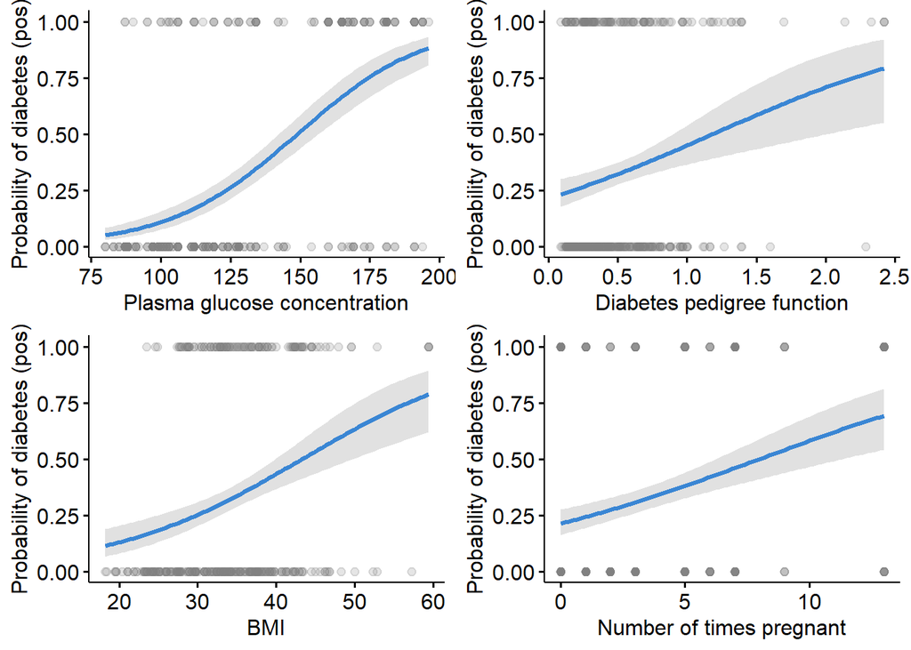

```r
library(ggpubr)

# 1. Assignation des graphiques à des objets (p1, p2, p3, p4)
p1 <- ggscatter(data2, x = "glucose", y = "diabetes", color = "grey50",
          alpha = 0.2, xlab = "Plasma glucose concentration",
          ylab = "Probability of diabetes (pos)") +
  geom_smooth(method = "glm", method.args = list(family = "binomial"),
              color = "#3a86d4", fill = "grey70")

p2 <- ggscatter(data2, x = "pedigree", y = "diabetes", color = "grey50",
          alpha = 0.2, xlab = "Diabetes pedigree function",
          ylab = "Probability of diabetes (pos)") +
  geom_smooth(method = "glm", method.args = list(family = "binomial"),
              color = "#3a86d4", fill = "grey70")

p3 <- ggscatter(data2, x = "mass", y = "diabetes", color = "grey50",
          alpha = 0.2, xlab = "BMI",
          ylab = "Probability of diabetes (pos)") +
  geom_smooth(method = "glm", method.args = list(family = "binomial"),
              color = "#3a86d4", fill = "grey70")

p4 <- ggscatter(data2, x = "pregnant", y = "diabetes", color = "grey50",
          alpha = 0.2, xlab = "Number of times pregnant",
          ylab = "Probability of diabetes (pos)") +
  geom_smooth(method = "glm", method.args = list(family = "binomial"),
              color = "#3a86d4", fill = "grey70")

# 2. Assemblage en 2x2 avec étiquettes A, B, C, D
fig_4panneaux <- ggarrange(
  p1, p2,
  p3, p4,
  ncol = 2, nrow = 2,
  label.x = 0.05,                 # Position horizontale des lettres
  label.y = 1.05,                 # Position verticale des lettres
  font.label = list(size = 12, face = "bold"),
  align = "hv"                    # Aligne les axes pour un rendu parfait
)

# 4. Affichage du résultat
fig_4panneaux
```

# **Conclusion**

The multiple imputation sensitivity analysis validates the core conclusions of the study while providing a more comprehensive and statistically powerful view of secondary risk factors. It confirms that clinical screening should prioritize glucose tolerance and genetic history, while acknowledging that BMI and pregnancy history play significant secondary roles in early detection.